# Reproducible Research: Peer Assessment 1

### Loading and preprocessing the data

Using **read_csv** function from readr package which automatically format dates

```r
library(tidyverse)
Sys.setlocale("LC_ALL","ENGLISH")#because my systems works in Russian
```

```
## [1] "LC_COLLATE=English_United States.1252;LC_CTYPE=English_United States.1252;LC_MONETARY=English_United States.1252;LC_NUMERIC=C;LC_TIME=English_United States.1252"
```

```r
url<-"https://d396qusza40orc.cloudfront.net/repdata%2Fdata%2Factivity.zip"

if(!file.exists("rawzip.zip")){
  download.file(url,destfile="rawzip.zip")
}
unzip("rawzip.zip")
my_data<-read_csv("activity.csv")
```

Structure of the data

```r
str(my_data)
```

```
## tibble [17,568 x 3] (S3: spec_tbl_df/tbl_df/tbl/data.frame)
##  $ steps   : num [1:17568] NA NA NA NA NA NA NA NA NA NA ...
##  $ date    : Date[1:17568], format: "2012-10-01" "2012-10-01" ...
##  $ interval: num [1:17568] 0 5 10 15 20 25 30 35 40 45 ...
##  - attr(*, "spec")=
##   .. cols(
##   ..   steps = col_double(),
##   ..   date = col_date(format = ""),
##   ..   interval = col_double()
##   .. )
```

### What is mean total number of steps taken per day?

##### Calculate the total number of steps taken per day

using **group_by** function we will group our data frame by date, and then using **summarise** function to find total steps per day

```r
steps_per_day<-my_data%>%group_by(date)%>%
  summarise(total_steps=sum(steps))
```

```r
head(steps_per_day)
```

```
## # A tibble: 6 x 2
##   date       total_steps
##   <date>           <dbl>
## 1 2012-10-01          NA
## 2 2012-10-02         126
## 3 2012-10-03       11352
## 4 2012-10-04       12116
## 5 2012-10-05       13294
## 6 2012-10-06       15420
```

In the code above , I used **%>%** which is calles pipe. It helps to avoid writing which data to use in each function, and allows to avoid nested functions

##### Make a histogram of the total number of steps taken each day

Usng ggplot2 package,and **geom_col** function we can constract bar plot using original data

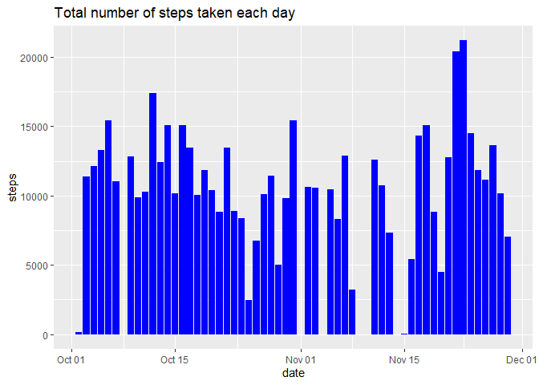

```r
ggplot(my_data)+geom_col(aes(date,steps),fill="blue")+
  ggtitle("Total number of steps taken each day")
```

##### Calculate and report the mean and median of the total number of steps taken per day

Again using **group_by** and **summarise** functions

```r
mean_median_summary<-my_data%>%group_by(date)%>%
  summarise(mean=mean(steps,na.rn=TRUE),median=median(steps,na.rm=TRUE))
```

```r
head(mean_median_summary)
```

```
## # A tibble: 6 x 3
##   date         mean median
##   <date>      <dbl>  <dbl>
## 1 2012-10-01 NA         NA
## 2 2012-10-02  0.438      0
## 3 2012-10-03 39.4        0
## 4 2012-10-04 42.1        0
## 5 2012-10-05 46.2        0
## 6 2012-10-06 53.5        0
```

### What is the average daily activity pattern?

##### Make a time series plot of the 5-minute interval (x-axis) and the average number of steps taken, averaged across all days (y-axis)

Using **group_by** and **summarise** functions,and then applying **geom_line**

```r
time_series<-my_data%>%group_by(interval)%>%
  summarise(mean=mean(steps,na.rm=TRUE))
```

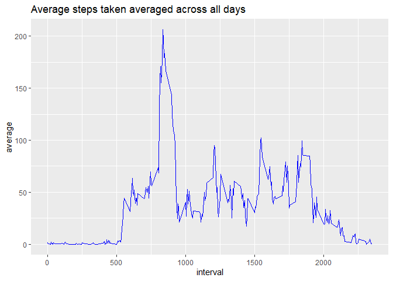

```r
ggplot(time_series)+geom_line(aes(interval,mean),color="blue")+
  ggtitle("Average steps taken averaged across all days")+ylab("average")
```

##### Which 5-minute interval, on average across all the days in the dataset, contains the maximum number of steps?

We actually can annotate our plot by adding vertical line(at max) using **geom_vline**  
To find which 5 minute interval has the maximum number of steps we can apply **which.max** function to number of steps and then use that index to find max 5 minute interval

```r
steps_per_interval<-my_data%>%group_by(interval)%>%
  summarise(average_steps=mean(steps,na.rm=TRUE))
head(steps_per_interval)
```

```
## # A tibble: 6 x 2
##   interval average_steps
##      <dbl>         <dbl>
## 1        0        1.72
## 2        5        0.340
## 3       10        0.132
## 4       15        0.151
## 5       20        0.0755
## 6       25        2.09
```

```r
max_index<-which.max(steps_per_interval$average_steps)
max_interval<-as.numeric(steps_per_interval[max_index,1])
```

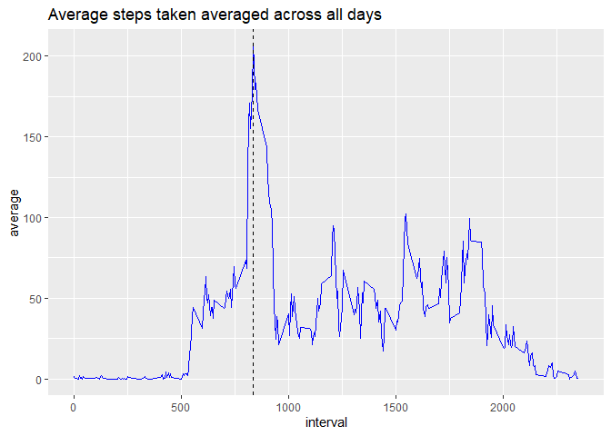

```r
ggplot(time_series)+geom_line(aes(interval,mean),color="blue")+
  ggtitle("Average steps taken averaged across all days")+ylab("average")+
  geom_vline(xintercept = max_interval,lty="dashed")
```

### Imputing missing values  
##### Calculate and report the total number of missing values in the dataset  
To find number we can use**map** function from purr package.

```r
map(my_data, ~sum(is.na(.)))
```

```
## $steps
## [1] 2304
##
## $date
## [1] 0
##
## $interval
## [1] 0
```

##### Devise a strategy for filling in all of the missing values in the dataset.

I decided to change Na_s with corresponding interval average. Fisrt of all i will **split** steps by interval. It will create a list with name attribute coresponding to interval.

```r
splitted_steps<-split(my_data$steps,my_data$interval)
head(splitted_steps,3)
```

```
## $`0`
##  [1] NA  0  0 47  0  0  0 NA  0 34  0  0  0  0  0  0  0  0  0  0  0 10  0  0  0
## [26]  0  0  0  0  0  0 NA  0  0 NA  0  0  0  0 NA NA  0  0  0 NA  0  0  0  0  0
## [51]  0  0  0  0  0  0  0  0  0  0 NA
##
## $`5`
##  [1] NA  0  0  0  0  0  0 NA  0 18  0  0  0  0  0  0  0  0  0  0  0  0  0  0  0
## [26]  0  0  0  0  0  0 NA  0  0 NA  0  0  0  0 NA NA  0  0  0 NA  0  0  0  0  0
## [51]  0  0  0  0  0  0  0  0  0  0 NA
##
## $`10`
##  [1] NA  0  0  0  0  0  0 NA  0  7  0  0  0  0  0  0  0  0  0  0  0  0  0  0  0
## [26]  0  0  0  0  0  0 NA  0  0 NA  0  0  0  0 NA NA  0  0  0 NA  0  0  0  0  0
## [51]  0  0  0  0  0  0  0  0  0  0 NA
```

Then using **select** function and previously applied group_by and summarise i will select only steps column and then convert it vector(in order to use in iterations)

```r
steps_per_interval_average<-my_data%>%group_by(interval)%>%
  summarise(average_steps=mean(steps,na.rm=TRUE))%>%select(average_steps)
interval_average<-unlist(steps_per_interval_average)
head(interval_average)
```

```
## average_steps1 average_steps2 average_steps3 average_steps4 average_steps5
##      1.7169811      0.3396226      0.1320755      0.1509434      0.0754717
## average_steps6
##      2.0943396
```

Using **map2** function we could create corrected list,where all NAs are replaced. **map2** function iterate 2 objects simultaneosly. It take first argument of splitted_steps(recorded steps is 0th interval),takes fisrt argument of interval_average(average steps in 0th interval) and finally using **replace_na** replace all NAs in 0th interval with 0th interval average. And this process repeats untill all objects iterated

```r
corrected_list<-map2(splitted_steps,interval_average,replace_na)
head(corrected_list,3)
```

```
## $`0`
##  [1]  1.716981  0.000000  0.000000 47.000000  0.000000  0.000000  0.000000
##  [8]  1.716981  0.000000 34.000000  0.000000  0.000000  0.000000  0.000000
## [15]  0.000000  0.000000  0.000000  0.000000  0.000000  0.000000  0.000000
## [22] 10.000000  0.000000  0.000000  0.000000  0.000000  0.000000  0.000000
## [29]  0.000000  0.000000  0.000000  1.716981  0.000000  0.000000  1.716981
## [36]  0.000000  0.000000  0.000000  0.000000  1.716981  1.716981  0.000000
## [43]  0.000000  0.000000  1.716981  0.000000  0.000000  0.000000  0.000000
## [50]  0.000000  0.000000  0.000000  0.000000  0.000000  0.000000  0.000000
## [57]  0.000000  0.000000  0.000000  0.000000  1.716981
##
## $`5`
##  [1]  0.3396226  0.0000000  0.0000000  0.0000000  0.0000000  0.0000000
##  [7]  0.0000000  0.3396226  0.0000000 18.0000000  0.0000000  0.0000000
## [13]  0.0000000  0.0000000  0.0000000  0.0000000  0.0000000  0.0000000
```

[output cut: 19 more lines]

##### Create a new dataset that is equal to the original dataset but with the missing data filled in

```r
corrected_steps<-as.numeric(unlist(corrected_list))
length(corrected_steps)==nrow(my_data)
```

```
## [1] TRUE
```

```r
corrected_data<-my_data
corrected_data$steps<-corrected_steps
map(corrected_data, ~sum(is.na(.)))
```

```
## $steps
## [1] 0
##
## $date
## [1] 0
##
## $interval
## [1] 0
```

Let’s compare plots with and withoud missiong values using **gridExtra** package

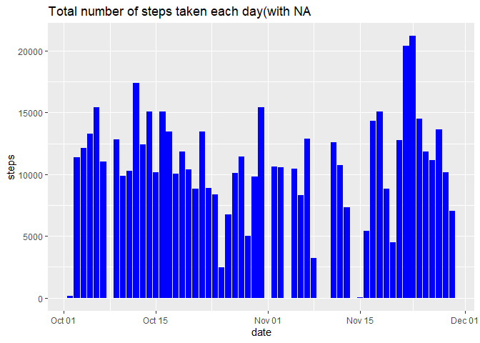

```r
with_na<-ggplot(my_data)+geom_col(aes(date,steps),fill="blue")+
  ggtitle("Total number of steps taken each day(with NA")
without_na<-ggplot(corrected_data)+
  geom_col(aes(date,steps),fill="red")+
  ggtitle("Total number of steps taken each day(without NA")
library(gridExtra)
with_na
```

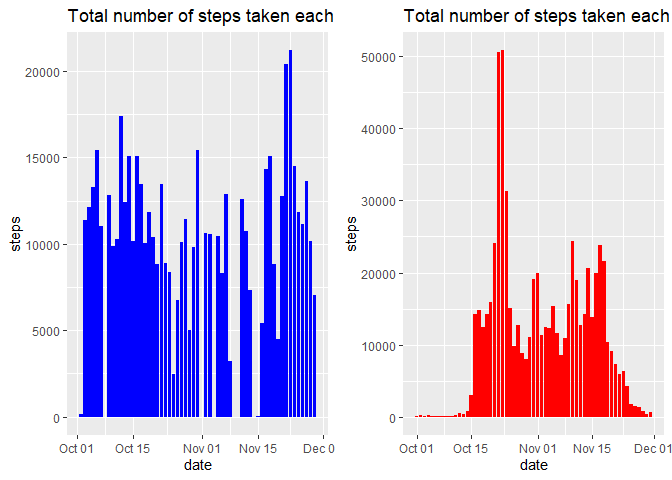

```r
grid.arrange(with_na,without_na,nrow=1)
```

### Are there differences in activity patterns between weekdays and weekends?

```r
library(lubridate)
new_data<-mutate(corrected_data,weekday=as.numeric(wday(date)<=5))
head(new_data)
```

```
## # A tibble: 6 x 4
##   steps date       interval weekday
##   <dbl> <date>        <dbl>   <dbl>
## 1  1.72 2012-10-01        0       1
## 2  0    2012-10-01        5       1
## 3  0    2012-10-01       10       1
## 4 47    2012-10-01       15       1
## 5  0    2012-10-01       20       1
## 6  0    2012-10-01       25       1
```

```r
new_data$weekday<-factor(new_data$weekday,levels=c(0,1),
                         labels=c("weekend","weekday"))
head(new_data)
```

```
## # A tibble: 6 x 4
##   steps date       interval weekday
##   <dbl> <date>        <dbl> <fct>
## 1  1.72 2012-10-01        0 weekday
## 2  0    2012-10-01        5 weekday
## 3  0    2012-10-01       10 weekday
## 4 47    2012-10-01       15 weekday
## 5  0    2012-10-01       20 weekday
## 6  0    2012-10-01       25 weekday
```

Contracting new plot

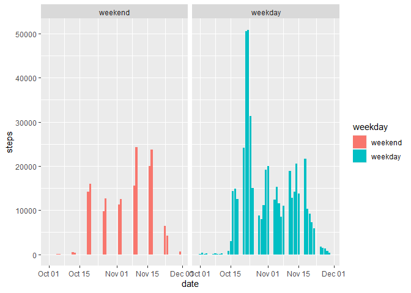

```r
ggplot(new_data)+geom_col(aes(date,steps,fill=weekday))+
  facet_grid(.~weekday)
```

###### Make a panel plot containing a time series plot

Final plot

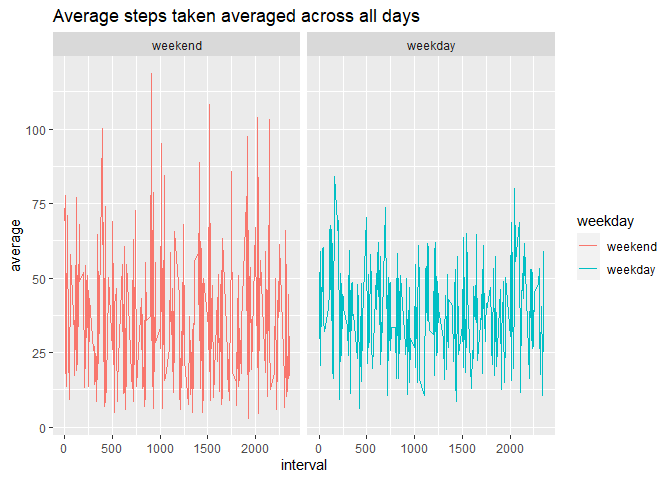

```r
corrected_time_series<-new_data%>%group_by(interval,weekday)%>%
  summarise(mean=mean(steps,na.rm=TRUE))
ggplot(corrected_time_series)+
  geom_line(aes(interval,mean,color=weekday))+
  ggtitle("Average steps taken averaged across all days")+ylab("average")+facet_grid(.~weekday)
```